# Final Project

Haichen Wei

Dec 13, 2020

# Which is a Better Choice for Breakfast, Cereals, Starbucks or McDonald’s?

## Introduction

This project will compare the nutrition facts cereal products, Starbucks and McDonald’s menu, and tell people which one is better to choose as breakfast. This analysis uses three dataset, all of them come from Kaggle. These datasets provide some basic nutrition facts of food, such as Calories, Fat, Protein and so on. Each dataset has different numbers of columns, so this analysis only choose the common columns of them.

## Importance of Exploring Nutrition Facts

Lots of people need to go to work or school in the morning. If they don’t get up early, they don’t have much time to prepare meal. At this moment, fast food becomes a easy way to deal with the breakfast. Cereal is the most common products for breakfast, you can easily make it at home. The Starbucks and McDonald’s are also popular choices, people can buy something ready to eat there. Fast food can save time, however, we also need to eat healthy. This project helps to analyze the nutritions of three fast food, and summary which fast foof is better.

## Set Up

### Clean up environment and load packages

```r
# clean up the RStudio environment
rm(list = ls())

# load all packages here:
library(tidyverse)
library(mosaic)
library(DataComputing)
library(dplyr)
library(pryr)
```

## Data Access

The description of 80 Cereals says it contains 80 kinds of cereals, but the dataset only have 77 cases in total, and it has 16 columns. Starbucks contains 113 cases and 6 columns. McDonalds has 260 cases and 24 columns. Since each dataset has different number of columns, so I choose the variables in common. Three datasets have 6 common variables, name, Calories, Fat, Carb., Fiber, Protein.

### Cereals

```r
# read the dataset
Cereals <- read.csv("/Users/Zoey/Desktop/cereal.csv")
# inspect data
glimpse(Cereals)
```

```
Rows: 77
Columns: 16
$ name     <fct> 100% Bran, 100% Natural Bran, All-Bran, All-Bran wit…
$ mfr      <fct> N, Q, K, K, R, G, K, G, R, P, Q, G, G, G, G, R, K, K…
$ type     <fct> C, C, C, C, C, C, C, C, C, C, C, C, C, C, C, C, C, C…
$ calories <int> 70, 120, 70, 50, 110, 110, 110, 130, 90, 90, 120, 11…
$ protein  <int> 4, 3, 4, 4, 2, 2, 2, 3, 2, 3, 1, 6, 1, 3, 1, 2, 2, 1…
$ fat      <int> 1, 5, 1, 0, 2, 2, 0, 2, 1, 0, 2, 2, 3, 2, 1, 0, 0, 0…
$ sodium   <int> 130, 15, 260, 140, 200, 180, 125, 210, 200, 210, 220…
$ fiber    <dbl> 10.0, 2.0, 9.0, 14.0, 1.0, 1.5, 1.0, 2.0, 4.0, 5.0, …
$ carbo    <dbl> 5.0, 8.0, 7.0, 8.0, 14.0, 10.5, 11.0, 18.0, 15.0, 13…
$ sugars   <int> 6, 8, 5, 0, 8, 10, 14, 8, 6, 5, 12, 1, 9, 7, 13, 3, …
$ potass   <int> 280, 135, 320, 330, -1, 70, 30, 100, 125, 190, 35, 1…
$ vitamins <int> 25, 0, 25, 25, 25, 25, 25, 25, 25, 25, 25, 25, 25, 2…
$ shelf    <int> 3, 3, 3, 3, 3, 1, 2, 3, 1, 3, 2, 1, 2, 3, 2, 1, 1, 2…
$ weight   <dbl> 1.00, 1.00, 1.00, 1.00, 1.00, 1.00, 1.00, 1.33, 1.00…
$ cups     <dbl> 0.33, 1.00, 0.33, 0.50, 0.75, 0.75, 1.00, 0.75, 0.67…
$ rating   <dbl> 68.40297, 33.98368, 59.42551, 93.70491, 34.38484, 29…
```

### Starbucks

```r
# read the dataset
Starbucks <- read.csv("/Users/Zoey/Desktop/food.csv")
# inspect data
names(Starbucks)
```

```
[1] "item"        "Calories"    "Fat..g."     "Carb...g."
[5] "Fiber..g."   "Protein..g."
```

```r
nrow(Starbucks)
```

```
[1] 113
```

### McDonald’s

```r
# read the dataset
McDonalds <- read.csv("/Users/Zoey/Desktop/menu.csv")
# inspect data
str(McDonalds)
```

```
'data.frame':   260 obs. of  24 variables:
 $ Category                     : Factor w/ 9 levels "Beef & Pork",..: 3 3 3 3 3 3 3 3 3 3 ...
 $ Item                         : Factor w/ 260 levels "1% Low Fat Milk Jug",..: 76 77 228 229 230 245 12 11 14 13 ...
 $ Serving.Size                 : Factor w/ 107 levels "1 carton (236 ml)",..: 55 54 42 69 69 83 63 72 65 73 ...
 $ Calories                     : int  300 250 370 450 400 430 460 520 410 470 ...
 $ Calories.from.Fat            : int  120 70 200 250 210 210 230 270 180 220 ...
 $ Total.Fat                    : num  13 8 23 28 23 23 26 30 20 25 ...
 $ Total.Fat....Daily.Value.    : int  20 12 35 43 35 36 40 47 32 38 ...
 $ Saturated.Fat                : num  5 3 8 10 8 9 13 14 11 12 ...
 $ Saturated.Fat....Daily.Value.: int  25 15 42 52 42 46 65 68 56 59 ...
 $ Trans.Fat                    : num  0 0 0 0 0 1 0 0 0 0 ...
 $ Cholesterol                  : int  260 25 45 285 50 300 250 250 35 35 ...
 $ Cholesterol....Daily.Value.  : int  87 8 15 95 16 100 83 83 11 11 ...
 $ Sodium                       : int  750 770 780 860 880 960 1300 1410 1300 1420 ...
 $ Sodium....Daily.Value.       : int  31 32 33 36 37 40 54 59 54 59 ...
 $ Carbohydrates                : int  31 30 29 30 30 31 38 43 36 42 ...
 $ Carbohydrates....Daily.Value.: int  10 10 10 10 10 10 13 14 12 14 ...
 $ Dietary.Fiber                : int  4 4 4 4 4 4 2 3 2 3 ...
 $ Dietary.Fiber....Daily.Value.: int  17 17 17 17 17 18 7 12 7 12 ...
 $ Sugars                       : int  3 3 2 2 2 3 3 4 3 4 ...
 $ Protein                      : int  17 18 14 21 21 26 19 19 20 20 ...
 $ Vitamin.A....Daily.Value.    : int  10 6 8 15 6 15 10 15 2 6 ...
 $ Vitamin.C....Daily.Value.    : int  0 0 0 0 0 2 8 8 8 8 ...
 $ Calcium....Daily.Value.      : int  25 25 25 30 25 30 15 20 15 15 ...
 $ Iron....Daily.Value.         : int  15 8 10 15 10 20 15 20 10 15 ...
```

## Data Wrangling

### Cereals

```r
# select common variables and rename it, add a type colomn
Cereals <-
  Cereals %>%
  mutate(Type = "Cereal") %>%
  select(name, Type, calories, protein, fat, fiber, carbo) %>%
  rename(Item = `name`,
         Calories = `calories`,
         Protein = `protein`,
         Fat = `fat`,
         Fiber = `fiber`,
         Carb. = `carbo`)
Cereals
```

| Item | Type | Calories | Protein | Fat | Fiber | Carb. |
| --- | --- | --- | --- | --- | --- | --- |
| 100% Bran | Cereal | 70 | 4 | 1 | 10.0 | 5.0 |
| 100% Natural Bran | Cereal | 120 | 3 | 5 | 2.0 | 8.0 |
| All-Bran | Cereal | 70 | 4 | 1 | 9.0 | 7.0 |
| All-Bran with Extra Fiber | Cereal | 50 | 4 | 0 | 14.0 | 8.0 |
| Almond Delight | Cereal | 110 | 2 | 2 | 1.0 | 14.0 |
| Apple Cinnamon Cheerios | Cereal | 110 | 2 | 2 | 1.5 | 10.5 |
| Apple Jacks | Cereal | 110 | 2 | 0 | 1.0 | 11.0 |
| Basic 4 | Cereal | 130 | 3 | 2 | 2.0 | 18.0 |
| Bran Chex | Cereal | 90 | 2 | 1 | 4.0 | 15.0 |
| Bran Flakes | Cereal | 90 | 3 | 0 | 5.0 | 13.0 |

[output cut: 67 more lines]

### Starbucks

```r
# add a type column to Starbucks and rename the variables
Starbucks <-
  Starbucks %>%
  mutate(Type = "Starbucks") %>%
  rename(Item = `item`,
         Protein = `Protein..g.`,
         Fat = `Fat..g.`,
         Fiber = `Fiber..g.`,
         Carb. = `Carb...g.`)
Starbucks
```

| Item | Calories | Fat | Carb. | Fiber | Protein | Type |
| --- | --- | --- | --- | --- | --- | --- |
| Chonga Bagel | 300 | 5.0 | 50 | 3 | 12 | Starbucks |
| 8-Grain Roll | 380 | 6.0 | 70 | 7 | 10 | Starbucks |
| Almond Croissant | 410 | 22.0 | 45 | 3 | 10 | Starbucks |
| Apple Fritter | 460 | 23.0 | 56 | 2 | 7 | Starbucks |
| Banana Nut Bread | 420 | 22.0 | 52 | 2 | 6 | Starbucks |
| Blueberry Muffin with Yogurt and Honey | 380 | 16.0 | 53 | 1 | 6 | Starbucks |
| Blueberry Scone | 420 | 17.0 | 61 | 2 | 5 | Starbucks |
| Butter Croissant | 240 | 12.0 | 28 | 1 | 5 | Starbucks |
| Butterfly Cookie | 350 | 22.0 | 38 | 0 | 2 | Starbucks |
| Cheese Danish | 320 | 16.0 | 36 | 1 | 8 | Starbucks |

[output cut: 103 more lines]

### McDonald’s

```r
#spread category
McDonalds %>%
  group_by(Item, Category) %>%
  summarise(total = sum(Calories))%>%
  spread(key = Category, value = total, fill = 0)
```

| Item | Beef & Pork | Beverages | Breakfast | Chicken & Fish | Coffee & Tea | Desserts | Salads | Smoothies & Shakes | Snacks & Sides |
| --- | --- | --- | --- | --- | --- | --- | --- | --- | --- |
| 1% Low Fat Milk Jug | 0 | 100 | 0 | 0 | 0 | 0 | 0 | 0 | 0 |
| Apple Slices | 0 | 0 | 0 | 0 | 0 | 0 | 0 | 0 | 15 |
| Bacon Buffalo Ranch McChicken | 0 | 0 | 0 | 430 | 0 | 0 | 0 | 0 | 0 |
| Bacon Cheddar McChicken | 0 | 0 | 0 | 480 | 0 | 0 | 0 | 0 | 0 |
| Bacon Clubhouse Burger | 720 | 0 | 0 | 0 | 0 | 0 | 0 | 0 | 0 |
| Bacon Clubhouse Crispy Chicken Sandwich | 0 | 0 | 0 | 750 | 0 | 0 | 0 | 0 | 0 |
| Bacon Clubhouse Grilled Chicken Sandwich | 0 | 0 | 0 | 590 | 0 | 0 | 0 | 0 | 0 |
| Bacon McDouble | 440 | 0 | 0 | 0 | 0 | 0 | 0 | 0 | 0 |
| Bacon, Egg & Cheese Bagel | 0 | 0 | 620 | 0 | 0 | 0 | 0 | 0 | 0 |
| Bacon, Egg & Cheese Bagel with Egg Whites | 0 | 0 | 570 | 0 | 0 | 0 | 0 | 0 | 0 |

[output cut: 250 more lines]

```r
#find the item which has egg or sausage
McDonalds %>%
  filter(grepl("Sausage|Egg",Item))
```

| Category | Item | Serving.Size | Calories | Calories.from.Fat | Total.Fat | Total.Fat....Daily.Value. | Saturated.Fat | Saturated.Fat....Daily.Value. | Trans.Fat | Cholesterol | Cholesterol....Daily.Value. | Sodium | Sodium....Daily.Value. | Carbohydrates | Carbohydrates....Daily.Value. | Dietary.Fiber | Dietary.Fiber....Daily.Value. | Sugars | Protein | Vitamin.A....Daily.Value. | Vitamin.C....Daily.Value. | Calcium....Daily.Value. | Iron....Daily.Value. |
| --- | --- | --- | --- | --- | --- | --- | --- | --- | --- | --- | --- | --- | --- | --- | --- | --- | --- | --- | --- | --- | --- | --- | --- |
| Breakfast | Egg McMuffin | 4.8 oz (136 g) | 300 | 120 | 13 | 20 | 5 | 25 | 0.0 | 260 | 87 | 750 | 31 | 31 | 10 | 4 | 17 | 3 | 17 | 10 | 0 | 25 | 15 |
| Breakfast | Egg White Delight | 4.8 oz (135 g) | 250 | 70 | 8 | 12 | 3 | 15 | 0.0 | 25 | 8 | 770 | 32 | 30 | 10 | 4 | 17 | 3 | 18 | 6 | 0 | 25 | 8 |
| Breakfast | Sausage McMuffin | 3.9 oz (111 g) | 370 | 200 | 23 | 35 | 8 | 42 | 0.0 | 45 | 15 | 780 | 33 | 29 | 10 | 4 | 17 | 2 | 14 | 8 | 0 | 25 | 10 |
| Breakfast | Sausage McMuffin with Egg | 5.7 oz (161 g) | 450 | 250 | 28 | 43 | 10 | 52 | 0.0 | 285 | 95 | 860 | 36 | 30 | 10 | 4 | 17 | 2 | 21 | 15 | 0 | 30 | 15 |
| Breakfast | Sausage McMuffin with Egg Whites | 5.7 oz (161 g) | 400 | 210 | 23 | 35 | 8 | 42 | 0.0 | 50 | 16 | 880 | 37 | 30 | 10 | 4 | 17 | 2 | 21 | 6 | 0 | 25 | 10 |
| Breakfast | Steak & Egg McMuffin | 6.5 oz (185 g) | 430 | 210 | 23 | 36 | 9 | 46 | 1.0 | 300 | 100 | 960 | 40 | 31 | 10 | 4 | 18 | 3 | 26 | 15 | 2 | 30 | 20 |
| Breakfast | Bacon, Egg & Cheese Biscuit (Regular Biscuit) | 5.3 oz (150 g) | 460 | 230 | 26 | 40 | 13 | 65 | 0.0 | 250 | 83 | 1300 | 54 | 38 | 13 | 2 | 7 | 3 | 19 | 10 | 8 | 15 | 15 |
| Breakfast | Bacon, Egg & Cheese Biscuit (Large Biscuit) | 5.8 oz (164 g) | 520 | 270 | 30 | 47 | 14 | 68 | 0.0 | 250 | 83 | 1410 | 59 | 43 | 14 | 3 | 12 | 4 | 19 | 15 | 8 | 20 | 20 |
| Breakfast | Bacon, Egg & Cheese Biscuit with Egg Whites (Regular Biscuit) | 5.4 oz (153 g) | 410 | 180 | 20 | 32 | 11 | 56 | 0.0 | 35 | 11 | 1300 | 54 | 36 | 12 | 2 | 7 | 3 | 20 | 2 | 8 | 15 | 10 |
| Breakfast | Bacon, Egg & Cheese Biscuit with Egg Whites (Large Biscuit) | 5.9 oz (167 g) | 470 | 220 | 25 | 38 | 12 | 59 | 0.0 | 35 | 11 | 1420 | 59 | 42 | 14 | 3 | 12 | 4 | 20 | 6 | 8 | 15 | 15 |

[output cut: 21 more lines]

```r
# select common variables and add a type colomn
McDonalds <-
  McDonalds %>%
  filter(grepl("Breakfast", Category)) %>% #McDonald's has a categore column, so I only choose the breakfast food, and the total cases for breakfast is 42.
  mutate(Type = "McDonalds") %>%
  select(Item, Type, Calories, Total.Fat, Carbohydrates, Dietary.Fiber, Protein) %>%
  rename(Fat = `Total.Fat`,
         Fiber = `Dietary.Fiber`,
         Carb. = `Carbohydrates`)
McDonalds
```

| Item | Type | Calories | Fat | Carb. | Fiber | Protein |
| --- | --- | --- | --- | --- | --- | --- |
| Egg McMuffin | McDonalds | 300 | 13 | 31 | 4 | 17 |
| Egg White Delight | McDonalds | 250 | 8 | 30 | 4 | 18 |
| Sausage McMuffin | McDonalds | 370 | 23 | 29 | 4 | 14 |
| Sausage McMuffin with Egg | McDonalds | 450 | 28 | 30 | 4 | 21 |
| Sausage McMuffin with Egg Whites | McDonalds | 400 | 23 | 30 | 4 | 21 |
| Steak & Egg McMuffin | McDonalds | 430 | 23 | 31 | 4 | 26 |
| Bacon, Egg & Cheese Biscuit (Regular Biscuit) | McDonalds | 460 | 26 | 38 | 2 | 19 |
| Bacon, Egg & Cheese Biscuit (Large Biscuit) | McDonalds | 520 | 30 | 43 | 3 | 19 |
| Bacon, Egg & Cheese Biscuit with Egg Whites (Regular Biscuit) | McDonalds | 410 | 20 | 36 | 2 | 20 |
| Bacon, Egg & Cheese Biscuit with Egg Whites (Large Biscuit) | McDonalds | 470 | 25 | 42 | 3 | 20 |

[output cut: 32 more lines]

```r
# combine the table
Food <- rbind(Cereals, Starbucks, McDonalds)
Food
```

| Item | Type | Calories | Protein | Fat | Fiber | Carb. |
| --- | --- | --- | --- | --- | --- | --- |
| 100% Bran | Cereal | 70 | 4 | 1.0 | 10.0 | 5.0 |
| 100% Natural Bran | Cereal | 120 | 3 | 5.0 | 2.0 | 8.0 |
| All-Bran | Cereal | 70 | 4 | 1.0 | 9.0 | 7.0 |
| All-Bran with Extra Fiber | Cereal | 50 | 4 | 0.0 | 14.0 | 8.0 |
| Almond Delight | Cereal | 110 | 2 | 2.0 | 1.0 | 14.0 |
| Apple Cinnamon Cheerios | Cereal | 110 | 2 | 2.0 | 1.5 | 10.5 |
| Apple Jacks | Cereal | 110 | 2 | 0.0 | 1.0 | 11.0 |
| Basic 4 | Cereal | 130 | 3 | 2.0 | 2.0 | 18.0 |
| Bran Chex | Cereal | 90 | 2 | 1.0 | 4.0 | 15.0 |
| Bran Flakes | Cereal | 90 | 3 | 0.0 | 5.0 | 13.0 |

[output cut: 222 more lines]

```r
Range <-
  Food %>%
  group_by(Type) %>%
  summarise(range_cal=max(Calories)-min(Calories),
            range_protein=max(Protein)-min(Protein),
            range_fat=max(Fat)-min(Fat),
            range_fiber=max(Fiber)-min(Fiber),
            range_carb=max(Carb.)-min(Carb.))
Range
```

| Type | range_cal | range_protein | range_fat | range_fiber | range_carb |
| --- | --- | --- | --- | --- | --- |
| Cereal | 110 | 5 | 5 | 14 | 24 |
| McDonalds | 1000 | 35 | 56 | 6 | 101 |
| Starbucks | 560 | 33 | 37 | 21 | 75 |

```r
Mean <-
  Food %>%
  group_by(Type) %>%
  summarise(mean_cal=mean(Calories),
            mean_protein=mean(Protein),
            mean_fat=mean(Fat),
            mean_fiber=mean(Fiber),
            mean_carb=mean(Carb.))
Mean
```

| Type | mean_cal | mean_protein | mean_fat | mean_fiber | mean_carb |
| --- | --- | --- | --- | --- | --- |
| Cereal | 106.8831 | 2.545455 | 1.012987 | 2.151948 | 14.59740 |
| McDonalds | 526.6667 | 19.857143 | 27.690476 | 3.261905 | 49.76190 |
| Starbucks | 356.6372 | 11.469027 | 16.353982 | 2.849558 | 41.48673 |

```r
# gather the table
Mean <-
Mean %>%
  gather(key = variables, value = mean, mean_cal, mean_protein, mean_fat, mean_fiber, mean_carb)

Range <-
Range %>%
  gather(key = variables, value = range, range_cal, range_protein, range_fat, range_fiber, range_carb)
```

```r
#join the tables
Join <-
Range %>%
  full_join(Mean)
```

## Data Visualization

The scatter plot graph shows McDonald’s has the highest calories and fat overall. The most plots of Cereal are between 0 to 150, it has very low calories and fat. The plots of Starbucks are between 0 to 750, so the food is under 750 calories and 40 fat.The plots of McDonald’s covered from 150 to 1200 calories and 0 to 60 fat.

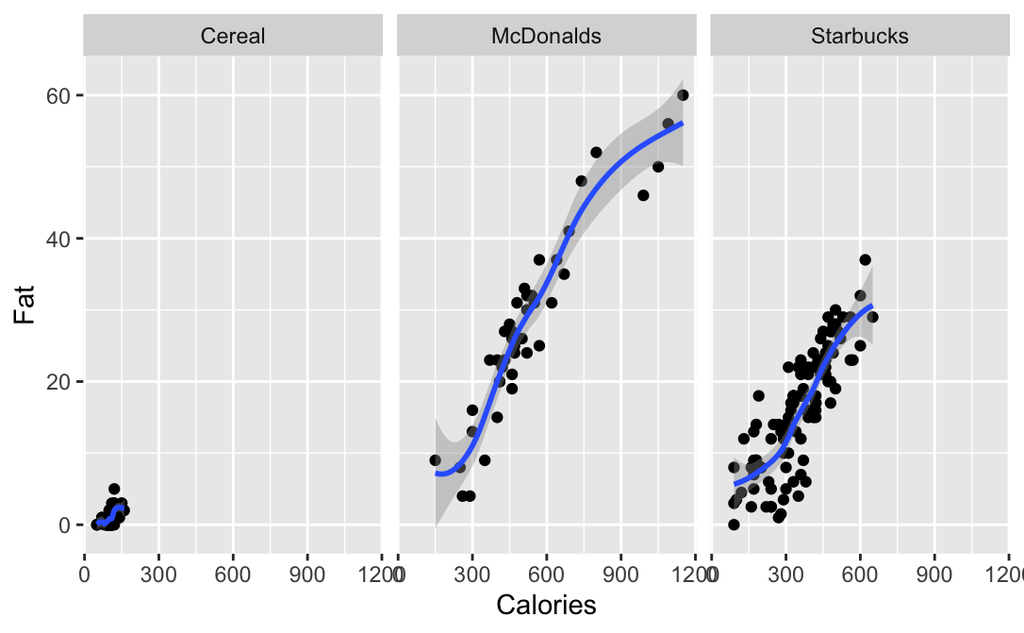

```r
ggplot(data=Food,aes(x=Calories,y=Fat ))+geom_point()+ facet_wrap(~Type,ncol=4) + stat_smooth(method = 'loess')
```

The following bar graph shows calorie has the largest range in the food, and the values of fiber are very small, it is almost covered by other variables.

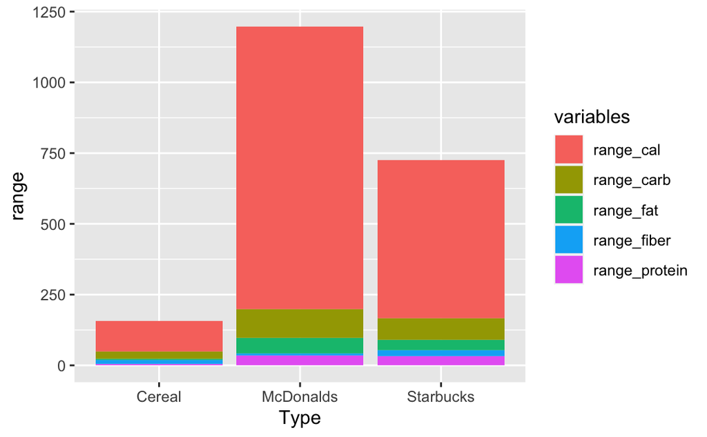

```r
ggplot(data=Range,aes(x=Type,y=range ,fill=variables))+geom_bar(stat='identity',position='stack', width=.9)
```

The following overlaid density distributions show that the food in Starbucks and McDonald’s has larger carbohydrates than cereals, and the fiber in these three types of food is very little.

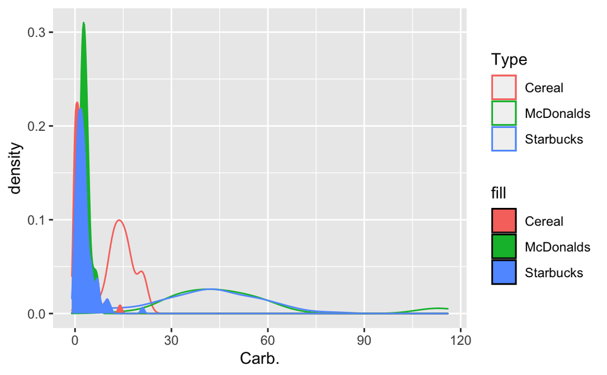

```r
ggplot(data=Food,aes(x = Carb., color=Type)) + geom_density() + geom_density(data=Food,aes(x = Fiber, fill=Type))
```

## Technical Challenge

The biggest technical challenge I encountered during the investigation is how to load the dataset from Kaggle. At first, I tried to use read.csv to read the file, but it came out a table of strings. I also tried read.file, and it didn’t work. Then, I found that we can down the csv file directly from the Kaggle website,so I download the csv file to my laptop and use read.csv to read the file.

## Reference

Crawford, C.(2017). 80 Cereals. Retrieved from https://www.kaggle.com/crawford/80-cereals?select=cereal.csv.

Starbucks.(2017). Nutrition facts for Starbucks Menu. https://www.kaggle.com/starbucks/starbucks-menu?select=starbucks-menu-nutrition-food.csv

McDonald.(2017). Nutrition Facts for McDonald’s Menu. https://www.kaggle.com/mcdonalds/nutrition-facts?select=menu.csv

## GitHub Links

https://hxw5245.github.io/STAT184FinalProject/

https://github.com/hxw5245/STAT184FinalProject.git